# The Holy Experiment

## Original Completion Dates

```
##    Min. 1st Qu.  Median    Mean 3rd Qu.    Max.    NA's
##    1700    1883    1902    1898    1922    1981      29
```

The earliest building in the table was completed in 1700. Philadelphia was originally settled in 1682, so this date is realistic for the area. The most recent building completed was in 1981, which seems a bit late, but it may have architectural significance that would put it on the register.

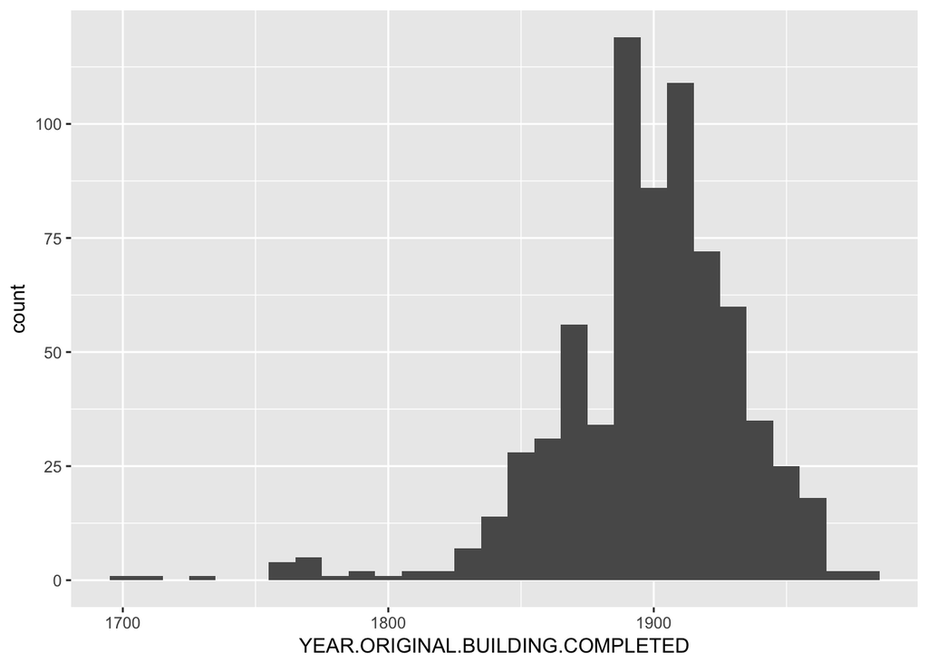

The highest completions were in the late 19th and early 20th centuries, which coincide with a boom in Philadelphia’s outlying neighborhoods, largely due to the increased availability of public transit, and the formation of streetcar suburbs.

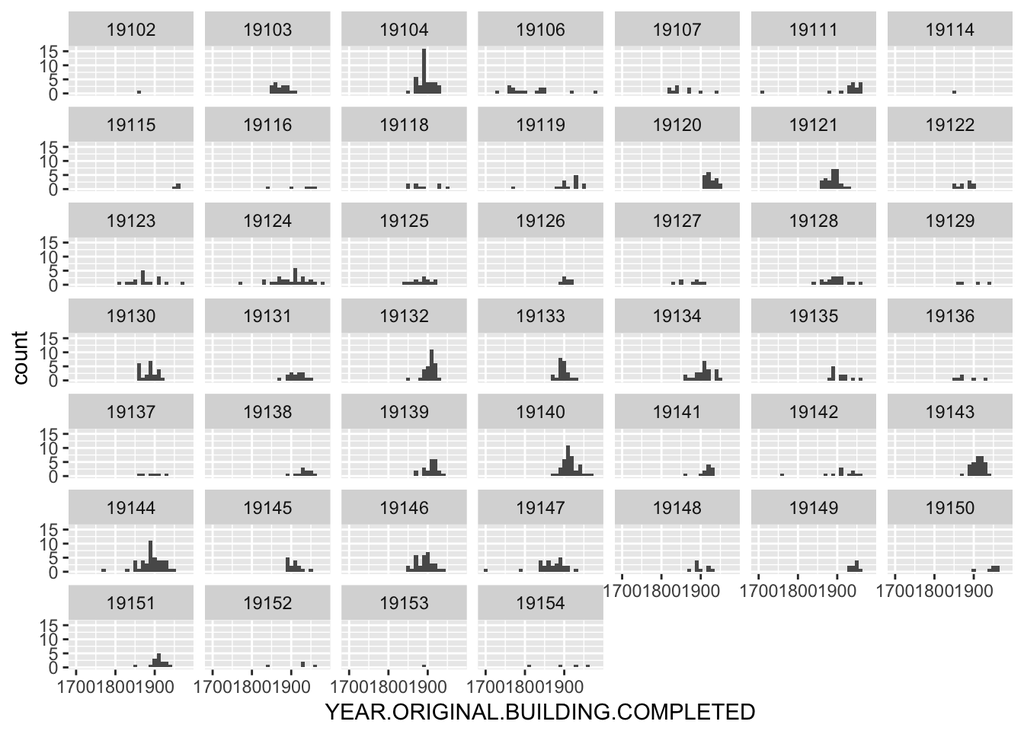

Completion years, faceted by zipcode. This will eventually be a GIS map as well, but the really active areas can be relatively easily picked out.

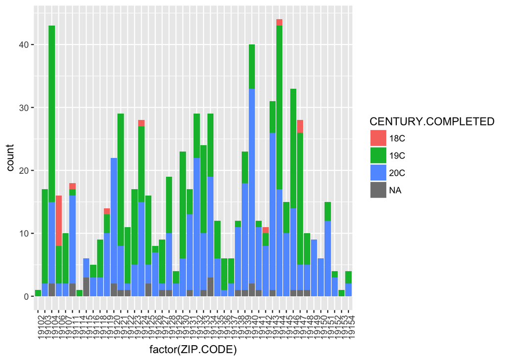

Showing the prevalance of 20th-century construction – although some zips noticeably see more growth earlier. These are probably the areas closest to Center City, where the bulk of Philadelphians lived until the early 20th century.

# Analysis

Although this is probably a dataset best shown off by the accompanying (eventually) GIS maps, it gives a good overview of when churches were being built in Philadelphia. Although founded in the late 1600’s, it’s clear that people didn’t really begin to move to outlying neighborhoods – requiring churches, synagogues, etc. – until the late 19th and early 20th centuries.

The zip code breakdowns can also serve as an interesting peek into the diversity of Philadelphia’s religious communities; this dataset represents a huge number of faiths, and it could be possible to trace movement of ethnic and national groups, among others, by how churches move, when they were built, and where they were built. I hypothesize that zipcodes with lots of construction, particularly in the 20th century, aren’t just showing a high population, but a very diverse one as well.

# Original Faiths Examined

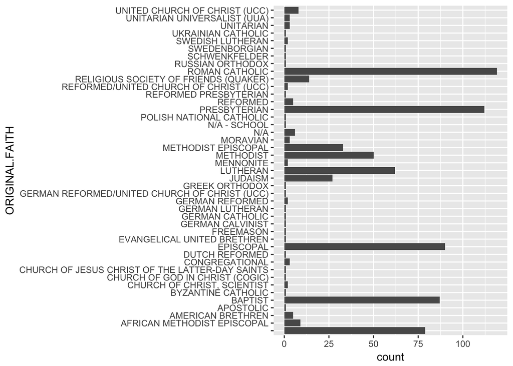

Churches broken down by original faith. Catholic, Presbytherian, Episcopal and Baptist all have the highest numbers of churches. Of note are the faiths that have disappeared or been folded into others over time, including German Calvinist, Swedenborgian, Schwenkfelder and American Brethren (which has a presence in Pennsylvania still).

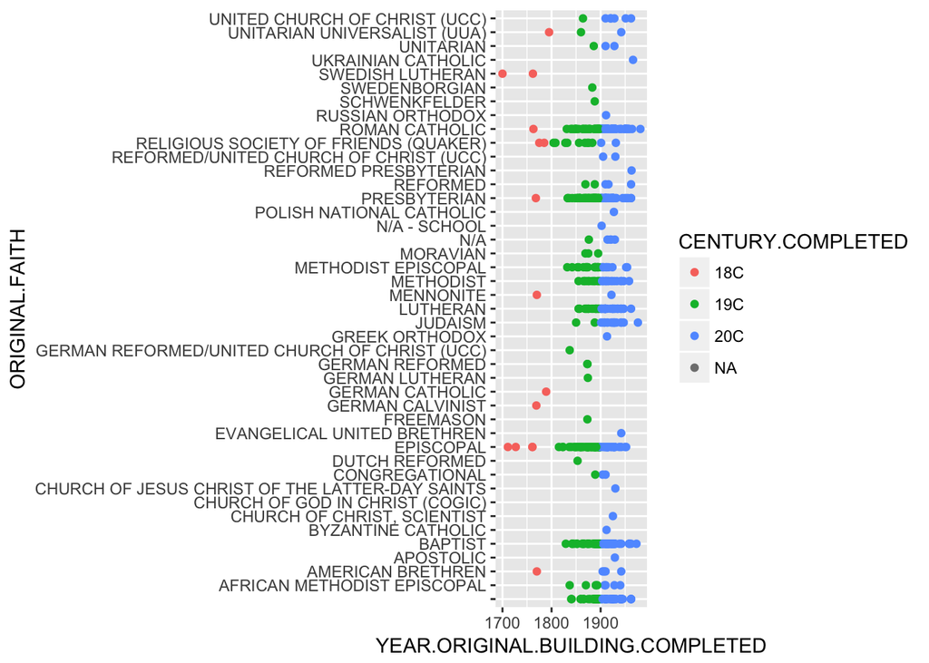

This graph shows the growth of various faiths over time, perhaps representing the changing demographics of Philadelphia. For example, until the mid-19th century, there were more Quaker meetinghouses than Roman Catholic churches.

# Analysis

The large number of faiths represented may well be unique to Philadelphia, or at least Pennsylvania, and speaks to the original purpose of the colony – to allow free practice of religion. It’s interesting to note that the faiths with the most churches generally don’t take off until well into the 19th century.

I’m also really interested by the American Brethren churches, of which one was built in the late 18th century, and then none until the 20th century.

Philadelphia’s immigrant history can also be traced to when churches start appearing, as with the Ukrainian Catholic church in the late 20th century. (It should be noted that these are specifically churches that appear on an historic register, and can therefore almost be considered sample of the total churches in Philadelphia. Real demographic analysis is probably best conducted with a larger, more random sample or the entire population.)

# Adaptive Reuse

| CURRENT.FAITH == "ADAPTIVE REUSE" | n |
| --- | --- |
| FALSE | 714 |
| TRUE | 33 |

33 properties are recorded as having ‘adaptive re-use’; they are still in use, but are no longer used for religious activities. The other 714 properties in the dataset are religous buildings, although possibly under a different faith.

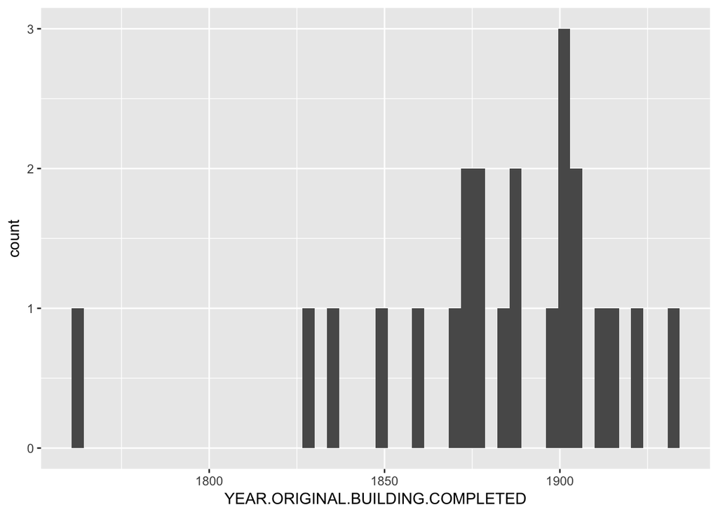

As with the dataset as a whole, the majority of buildings adaptively reused were originally completed in the late 19th and early 20th centuries.

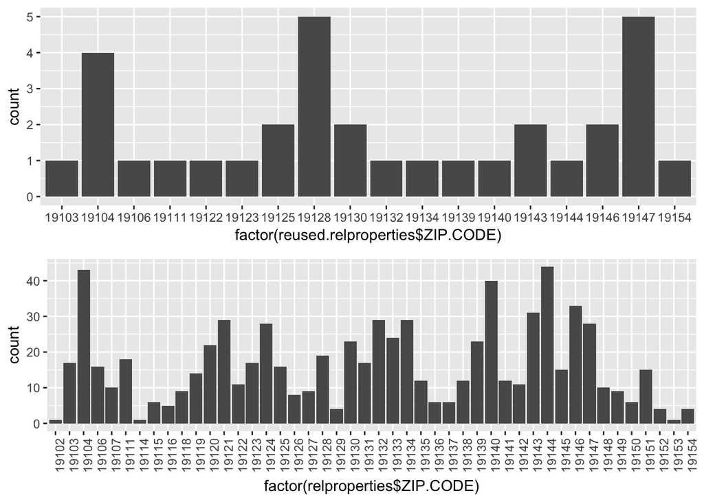

```r
a1 <- ggplot(aes(x=factor(reused.relproperties$ZIP.CODE)), data=reused.relproperties) +
  geom_histogram(stat='count')
a2 <- ggplot(aes(x=factor(relproperties$ZIP.CODE)), data=relproperties) +
  geom_histogram(stat='count') +
    theme(axis.text.x = element_text(angle = 90, hjust = 1))
grid.arrange(a1, a2, ncol=1)
```

Reused properties (top) compared to all properties, broken down by zip code.

19128 is a particularly interesting outlier – it has one of the highest counts of adaptive re-use, but doesn’t particularly stand out for property counts in the full dataset. 19104 and 19147 at least are on the higher end of overall number of religious properties.

# Properties that changed denomination

[figure not shown]

Original faith versus current faith.